# Prac_Mach_Learn_2

N3P2

16 October 2015

## Introduction

Using health tracking devices such as Jawbone Up, Nike FuelBand, and Fitbit it is now possible to collect a large amount of data about personal activity relatively inexpensively. These type of devices are part of the quantified self movement - a group of enthusiasts who take measurements about themselves regularly to improve their health, to find patterns in their behavior, or because they are tech geeks. One thing that people regularly do is quantify how much of a particular activity they do, but they rarely quantify how well they do it.

Data from accelerometers on the belt, forearm, arm, and dumbell of 6 participants were used to predict the manner in which they did the exercise.

## Data Preprocessing

```r
library(caret)
```

```r
library(rpart)
library(rpart.plot)
library(randomForest)
library(corrplot)
```

### Data download

```r
training.file   <- 'pml-training.csv'
test.cases.file <- 'pml-test.csv'
training.url    <- 'http://d396qusza40orc.cloudfront.net/predmachlearn/pml-training.csv'
test.cases.url  <- 'http://d396qusza40orc.cloudfront.net/predmachlearn/pml-testing.csv'

download.file(training.url, training.file)
download.file(test.cases.url,test.cases.file)
```

### Data read

Loading the data and reading the data sets on 2 frames

```r
trainRaw <- read.csv("pml-training.csv")
testRaw <- read.csv("pml-test.csv")
dim(trainRaw)
```

```
## [1] 19622   160
```

```r
dim(testRaw)
```

```
## [1]  20 160
```

The *training data set* contains **19622 observations and 160 variables**, while the *testing data set* contains **20 observations and 160 variables**.

## Cleaning Data

All blank(‘“”’), ‘#DIV/0’ and ‘NA’ values are converted to ‘NA’. Columns containing ‘NA’ were removed from both data sets.

```r
training.df   <-read.csv("pml-training.csv", na.strings=c("NA","#DIV/0!", ""))
test.cases.df <-read.csv("pml-test.csv" , na.strings=c("NA", "#DIV/0!", ""))
training.df<-training.df[,colSums(is.na(training.df)) == 0]
test.cases.df <-test.cases.df[,colSums(is.na(test.cases.df)) == 0]
```

The first 7 columns are not related to calculations thus removed from data sets. 1. *user_name* 2. *raw_timestamp_part_1* 3. *raw_timestamp_part_2* 4. *cvtd_timestamp* 5. *new_window* 6. *num_window*

```r
training.df   <-training.df[,-c(1:7)]
test.cases.df <-test.cases.df[,-c(1:7)]
```

Now, the cleaned training data set contains **19622 observations and 53 variables**, while the testing data set contains **20 observations and 53 variables**. The “classe” variable is still in the cleaned training set.

### Slice the data

```r
set.seed(22519) # For reproducibile purpose

inTrain <- createDataPartition(training.df$classe, p = 0.75, list = F)
trainData <- training.df[inTrain, ]
testData  <- training.df[-inTrain, ]
```

## Data Modeling

A predictive model was fitted for activity recognition using **Random Forest** algorithm due to automatic selection of important variables and robustness to correlated covariates & outliers in general. **5-fold cross validation** will be used when applying the algorithm.

```r
controlRf <- trainControl(method="cv", 5)
modelRf <- train(classe ~ ., data=trainData, method="rf", trControl=controlRf, ntree=250)
modelRf
```

```
## Random Forest
##
## 14718 samples
##    52 predictor
##     5 classes: 'A', 'B', 'C', 'D', 'E'
##
## No pre-processing
## Resampling: Cross-Validated (5 fold)
## Summary of sample sizes: 11776, 11775, 11775, 11773, 11773
## Resampling results across tuning parameters:
##
##   mtry  Accuracy   Kappa      Accuracy SD   Kappa SD
##    2    0.9914389  0.9891698  0.0008472351  0.001072009
##   27    0.9912350  0.9889124  0.0015647255  0.001979460
##   52    0.9857317  0.9819498  0.0021088807  0.002668672
##
## Accuracy was used to select the optimal model using  the largest value.
## The final value used for the model was mtry = 2.
```

Using *confusion matrix* to test the performance of the model on the validation data set.

```r
predictRf <- predict(modelRf, testData)
confusionMatrix(testData$classe, predictRf)
```

```
## Confusion Matrix and Statistics
##
##           Reference
## Prediction    A    B    C    D    E
##          A 1394    0    0    0    1
##          B    4  940    5    0    0
##          C    0    3  850    2    0
##          D    0    0   15  789    0
##          E    0    0    0    4  897
##
## Overall Statistics
##
##                Accuracy : 0.9931
##                  95% CI : (0.9903, 0.9952)
##     No Information Rate : 0.2851
##     P-Value [Acc > NIR] : < 2.2e-16
##
##                   Kappa : 0.9912
##  Mcnemar's Test P-Value : NA
##
## Statistics by Class:
##
##                      Class: A Class: B Class: C Class: D Class: E
## Sensitivity            0.9971   0.9968   0.9770   0.9925   0.9989
## Specificity            0.9997   0.9977   0.9988   0.9963   0.9990
## Pos Pred Value         0.9993   0.9905   0.9942   0.9813   0.9956
## Neg Pred Value         0.9989   0.9992   0.9951   0.9985   0.9998
## Prevalence             0.2851   0.1923   0.1774   0.1621   0.1831
## Detection Rate         0.2843   0.1917   0.1733   0.1609   0.1829
## Detection Prevalence   0.2845   0.1935   0.1743   0.1639   0.1837
## Balanced Accuracy      0.9984   0.9973   0.9879   0.9944   0.9989
```

```r
accuracy <- postResample(predictRf, testData$classe)
accuracy
```

```
##  Accuracy     Kappa
## 0.9930669 0.9912299
```

```r
error.rate <- 1 - as.numeric(confusionMatrix(testData$classe, predictRf)$overall[1])
error.rate
```

```
## [1] 0.006933116
```

## Test Data Set Prediction

```r
result <- predict(modelRf, test.cases.df[, -length(names(test.cases.df))])
result
```

```
##  [1] B A B A A E D B A A B C B A E E A B B B
## Levels: A B C D E
```

## Figures

1. Correlation Matrix Visualization

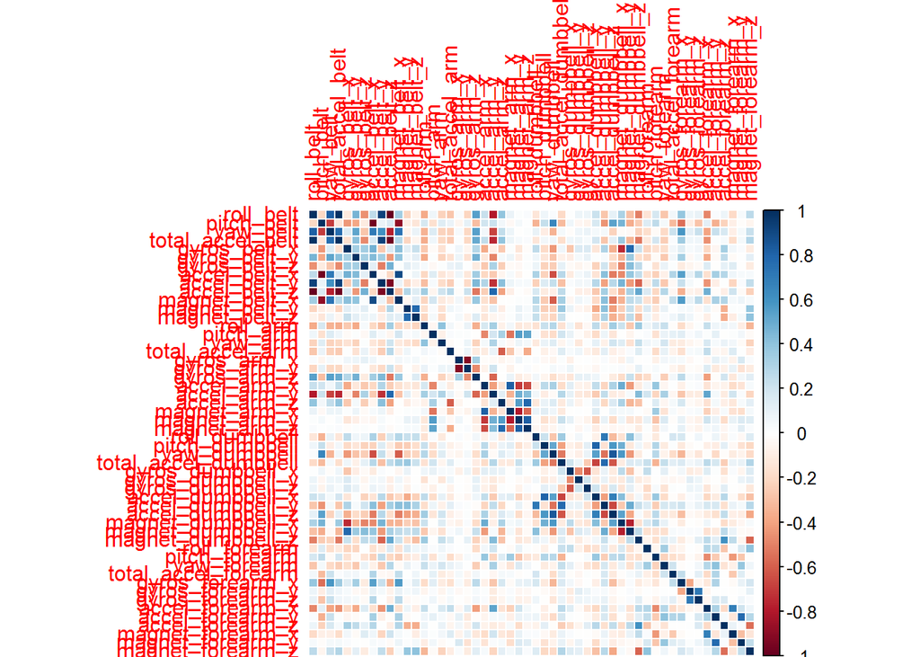

```r
corrPlot <- cor(trainData[, -length(names(trainData))])
corrplot(corrPlot, method="color")
```

2. Decision Tree Visualization

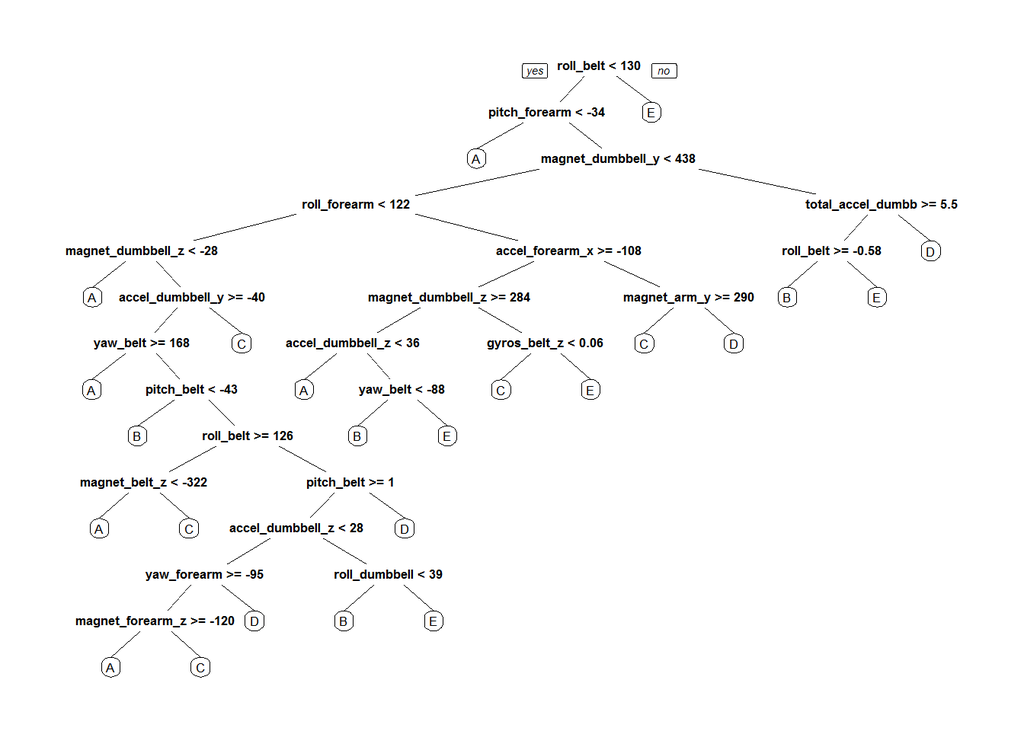

```r
treeModel <- rpart(classe ~ ., data=trainData, method="class")
prp(treeModel) # fast plot
```

## Coursera code for submission

```r
answers <- result
pml_write_files <- function(x){
  n = length(x)
  for(i in 1:n){
    filename = paste0("problem_id_",i,".txt")
    write.table(x[i], file=filename, quote=FALSE,
                row.names=FALSE, col.names=FALSE)
  }
}
pml_write_files(answers)
```